# Travel_Package_Purchase_Prediction

**Problem Statement**

You are a Data Scientist for a tourism company named "Visit with us". The Policy Maker of the company wants to enable and establish a viable business model to expand the customer base.

A viable business model is a central concept that helps you to understand the existing ways of doing the business and how to change the ways for the benefit of the tourism sector.

One of the ways to expand the customer base is to introduce a new offering of packages.

Currently, there are 5 types of packages the company is offering - Basic, Standard, Deluxe, Super Deluxe, King. Looking at the data of the last year, we observed that 18% of the customers purchased the packages.

However, it was difficult to identify the potential customers because customers were contacted at random without looking at the available information.

The company is now planning to launch a new product i.e. Wellness Tourism Package. Wellness Tourism is defined as Travel that allows the traveler to maintain, enhance or kick-start a healthy lifestyle, and support or increase one's sense of well-being.

This time company wants to harness the available data of existing and potential customers to target the right customers.

You as a Data Scientist at "Visit with us" travel company has to analyze the customers' data and information to provide recommendations to the Policy Maker and build a model to predict the potential customer who is going to purchase the newly introduced travel package. The model will be built to make predictions before a customer is contacted.

**Objective**

To predict which customer is more likely to purchase the newly introduced travel package.

**Data Dictionary**

Customer details:

- CustomerID: Unique customer ID
- ProdTaken: Whether the customer has purchased a package or not (0: No, 1: Yes)
- Age: Age of customer
- TypeofContact: How customer was contacted (Company Invited or Self Inquiry)
- CityTier: City tier depends on the development of a city, population, facilities, and living standards. The categories are ordered i.e. Tier 1 > Tier 2 > Tier 3. It's the city the customer lives in.
- Occupation: Occupation of customer
- Gender: Gender of customer
- NumberOfPersonVisiting: Total number of persons planning to take the trip with the customer
- PreferredPropertyStar: Preferred hotel property rating by customer
- MaritalStatus: Marital status of customer
- NumberOfTrips: Average number of trips in a year by customer
- Passport: The customer has a passport or not (0: No, 1: Yes)
- OwnCar: Whether the customers own a car or not (0: No, 1: Yes)
- NumberOfChildrenVisiting: Total number of children with age less than 5 planning to take the trip with the customer
- Designation: Designation of the customer in the current organization
- MonthlyIncome: Gross monthly income of the customer

**Customer interaction data:**

- PitchSatisfactionScore: Sales pitch satisfaction score
- ProductPitched: Product pitched by the salesperson
- NumberOfFollowups: Total number of follow-ups has been done by the salesperson after the sales pitch
- DurationOfPitch: Duration of the pitch by a salesperson to the customer

# Import necessary libraries

```python
import pandas as pd
import numpy as np
import matplotlib.pyplot as plt
import seaborn as sns

from sklearn import metrics
from sklearn.metrics import (
    accuracy_score,
    recall_score,
    precision_score,
    f1_score,
    confusion_matrix
)
from sklearn.model_selection import (
    GridSearchCV,
    train_test_split
)

from sklearn.tree import DecisionTreeClassifier
from sklearn.ensemble import (
    BaggingClassifier,
    RandomForestClassifier,
    AdaBoostClassifier,
    GradientBoostingClassifier,
    StackingClassifier
)

from xgboost import XGBClassifier
```

# Reading the dataset

```python
from google.colab import drive
drive.mount('/content/mydrive')
```

```python
path= '/content/mydrive/MyDrive/Python/Data Set/Tourism.xlsx'
df_tourism = pd.read_excel(io=path,sheet_name='Tourism')
```

**Overview of the dataset**

*Displaying the first and last 5 rows of the dataset*

```python
df_tourism.head()
```

|  | CustomerID | ProdTaken | Age | TypeofContact | CityTier | DurationOfPitch | Occupation | Gender | NumberOfPersonVisiting | NumberOfFollowups | ProductPitched | PreferredPropertyStar | MaritalStatus | NumberOfTrips | Passport | PitchSatisfactionScore | OwnCar | NumberOfChildrenVisiting | Designation | MonthlyIncome |
| --- | --- | --- | --- | --- | --- | --- | --- | --- | --- | --- | --- | --- | --- | --- | --- | --- | --- | --- | --- | --- |
| 0 | 200000 | 1 | 41.0 | Self Enquiry | 3 | 6.0 | Salaried | Female | 3 | 3.0 | Deluxe | 3.0 | Single | 1.0 | 1 | 2 | 1 | 0.0 | Manager | 20993.0 |
| 1 | 200001 | 0 | 49.0 | Company Invited | 1 | 14.0 | Salaried | Male | 3 | 4.0 | Deluxe | 4.0 | Divorced | 2.0 | 0 | 3 | 1 | 2.0 | Manager | 20130.0 |
| 2 | 200002 | 1 | 37.0 | Self Enquiry | 1 | 8.0 | Free Lancer | Male | 3 | 4.0 | Basic | 3.0 | Single | 7.0 | 1 | 3 | 0 | 0.0 | Executive | 17090.0 |
| 3 | 200003 | 0 | 33.0 | Company Invited | 1 | 9.0 | Salaried | Female | 2 | 3.0 | Basic | 3.0 | Divorced | 2.0 | 1 | 5 | 1 | 1.0 | Executive | 17909.0 |
| 4 | 200004 | 0 | NaN | Self Enquiry | 1 | 8.0 | Small Business | Male | 2 | 3.0 | Basic | 4.0 | Divorced | 1.0 | 0 | 5 | 1 | 0.0 | Executive | 18468.0 |

```python
df_tourism.tail()
```

|  | CustomerID | ProdTaken | Age | TypeofContact | CityTier | DurationOfPitch | Occupation | Gender | NumberOfPersonVisiting | NumberOfFollowups | ProductPitched | PreferredPropertyStar | MaritalStatus | NumberOfTrips | Passport | PitchSatisfactionScore | OwnCar | NumberOfChildrenVisiting | Designation | MonthlyIncome |
| --- | --- | --- | --- | --- | --- | --- | --- | --- | --- | --- | --- | --- | --- | --- | --- | --- | --- | --- | --- | --- |
| 4883 | 204883 | 1 | 49.0 | Self Enquiry | 3 | 9.0 | Small Business | Male | 3 | 5.0 | Deluxe | 4.0 | Unmarried | 2.0 | 1 | 1 | 1 | 1.0 | Manager | 26576.0 |
| 4884 | 204884 | 1 | 28.0 | Company Invited | 1 | 31.0 | Salaried | Male | 4 | 5.0 | Basic | 3.0 | Single | 3.0 | 1 | 3 | 1 | 2.0 | Executive | 21212.0 |
| 4885 | 204885 | 1 | 52.0 | Self Enquiry | 3 | 17.0 | Salaried | Female | 4 | 4.0 | Standard | 4.0 | Married | 7.0 | 0 | 1 | 1 | 3.0 | Senior Manager | 31820.0 |
| 4886 | 204886 | 1 | 19.0 | Self Enquiry | 3 | 16.0 | Small Business | Male | 3 | 4.0 | Basic | 3.0 | Single | 3.0 | 0 | 5 | 0 | 2.0 | Executive | 20289.0 |
| 4887 | 204887 | 1 | 36.0 | Self Enquiry | 1 | 14.0 | Salaried | Male | 4 | 4.0 | Basic | 4.0 | Unmarried | 3.0 | 1 | 3 | 1 | 2.0 | Executive | 24041.0 |

**Understand the shape of the dataset**

```python
df_tourism.shape
```

```
(4888, 20)
```

- There are 4888 observations and 20 columns in the dataset

**Check the data types of the columns for the dataset.**

```python
df_tourism.info()
```

```
<class 'pandas.core.frame.DataFrame'>
RangeIndex: 4888 entries, 0 to 4887
Data columns (total 20 columns):
 #   Column                    Non-Null Count  Dtype
---  ------                    --------------  -----
 0   CustomerID                4888 non-null   int64
 1   ProdTaken                 4888 non-null   int64
 2   Age                       4662 non-null   float64
 3   TypeofContact             4863 non-null   object
 4   CityTier                  4888 non-null   int64
 5   DurationOfPitch           4637 non-null   float64
 6   Occupation                4888 non-null   object
 7   Gender                    4888 non-null   object
 8   NumberOfPersonVisiting    4888 non-null   int64
 9   NumberOfFollowups         4843 non-null   float64
 10  ProductPitched            4888 non-null   object
 11  PreferredPropertyStar     4862 non-null   float64
 12  MaritalStatus             4888 non-null   object
 13  NumberOfTrips             4748 non-null   float64
 14  Passport                  4888 non-null   int64
 15  PitchSatisfactionScore    4888 non-null   int64
 16  OwnCar                    4888 non-null   int64
 17  NumberOfChildrenVisiting  4822 non-null   float64
 18  Designation               4888 non-null   object
 19  MonthlyIncome             4655 non-null   float64
dtypes: float64(7), int64(7), object(6)
memory usage: 763.9+ KB
```

**Observations:**

- There are 7 features having data type integer and float .
- There are 6 features having data type object.
- Total size of the dataset is 763.9 KB.

**Summary of the dataset**

```python
df_tourism.describe(include='all').T
```

|  | count | unique | top | freq | mean | std | min | 25% | 50% | 75% | max |
| --- | --- | --- | --- | --- | --- | --- | --- | --- | --- | --- | --- |
| CustomerID | 4888.0 | NaN | NaN | NaN | 202443.5 | 1411.188388 | 200000.0 | 201221.75 | 202443.5 | 203665.25 | 204887.0 |
| ProdTaken | 4888.0 | NaN | NaN | NaN | 0.188216 | 0.390925 | 0.0 | 0.0 | 0.0 | 0.0 | 1.0 |
| Age | 4662.0 | NaN | NaN | NaN | 37.622265 | 9.316387 | 18.0 | 31.0 | 36.0 | 44.0 | 61.0 |
| TypeofContact | 4863 | 2 | Self Enquiry | 3444 | NaN | NaN | NaN | NaN | NaN | NaN | NaN |
| CityTier | 4888.0 | NaN | NaN | NaN | 1.654255 | 0.916583 | 1.0 | 1.0 | 1.0 | 3.0 | 3.0 |
| DurationOfPitch | 4637.0 | NaN | NaN | NaN | 15.490835 | 8.519643 | 5.0 | 9.0 | 13.0 | 20.0 | 127.0 |
| Occupation | 4888 | 4 | Salaried | 2368 | NaN | NaN | NaN | NaN | NaN | NaN | NaN |
| Gender | 4888 | 3 | Male | 2916 | NaN | NaN | NaN | NaN | NaN | NaN | NaN |
| NumberOfPersonVisiting | 4888.0 | NaN | NaN | NaN | 2.905074 | 0.724891 | 1.0 | 2.0 | 3.0 | 3.0 | 5.0 |
| NumberOfFollowups | 4843.0 | NaN | NaN | NaN | 3.708445 | 1.002509 | 1.0 | 3.0 | 4.0 | 4.0 | 6.0 |
| ProductPitched | 4888 | 5 | Basic | 1842 | NaN | NaN | NaN | NaN | NaN | NaN | NaN |
| PreferredPropertyStar | 4862.0 | NaN | NaN | NaN | 3.581037 | 0.798009 | 3.0 | 3.0 | 3.0 | 4.0 | 5.0 |
| MaritalStatus | 4888 | 4 | Married | 2340 | NaN | NaN | NaN | NaN | NaN | NaN | NaN |
| NumberOfTrips | 4748.0 | NaN | NaN | NaN | 3.236521 | 1.849019 | 1.0 | 2.0 | 3.0 | 4.0 | 22.0 |
| Passport | 4888.0 | NaN | NaN | NaN | 0.290917 | 0.454232 | 0.0 | 0.0 | 0.0 | 1.0 | 1.0 |
| PitchSatisfactionScore | 4888.0 | NaN | NaN | NaN | 3.078151 | 1.365792 | 1.0 | 2.0 | 3.0 | 4.0 | 5.0 |
| OwnCar | 4888.0 | NaN | NaN | NaN | 0.620295 | 0.485363 | 0.0 | 0.0 | 1.0 | 1.0 | 1.0 |
| NumberOfChildrenVisiting | 4822.0 | NaN | NaN | NaN | 1.187267 | 0.857861 | 0.0 | 1.0 | 1.0 | 2.0 | 3.0 |
| Designation | 4888 | 5 | Executive | 1842 | NaN | NaN | NaN | NaN | NaN | NaN | NaN |
| MonthlyIncome | 4655.0 | NaN | NaN | NaN | 23619.853491 | 5380.698361 | 1000.0 | 20346.0 | 22347.0 | 25571.0 | 98678.0 |

**Observations:**

- Minimum and maximum age of the customers are 18 and 61 respectivily.
- Maximum customers are self enquired for tourist package.
- Minimum duration of the pitch by salesperson to customrs is 5 and maximum is 127 . Maximum pitch seems like very high compare to third qurtile and consider as outlier, will review further and decide.
- Maximum customers are salaried, male and married.
- Maximum product pitch given by sales person to customer is basic.
- Most of the customers having 'Executive' designation.
- Few features data rows are less than the total rows and need to check the missing values.

# Data Preprocessing

```python
# check null value counts
df_tourism.isnull().sum().sort_values(ascending=False)
```

```
DurationOfPitch             251
MonthlyIncome               233
Age                         226
NumberOfTrips               140
NumberOfChildrenVisiting     66
NumberOfFollowups            45
PreferredPropertyStar        26
TypeofContact                25
Designation                   0
OwnCar                        0
PitchSatisfactionScore        0
Passport                      0
CustomerID                    0
MaritalStatus                 0
ProdTaken                     0
NumberOfPersonVisiting        0
Gender                        0
Occupation                    0
CityTier                      0
ProductPitched                0
dtype: int64
```

```python
# Get Null data set for 'DurationOfPitch'
df_tourism.loc[df_tourism['DurationOfPitch'].isnull()]

# Update the null value with mean of 'DurationOfPitch'
df_tourism['DurationOfPitch'].fillna(df_tourism['DurationOfPitch'].mean(),inplace=True)
```

```python
# Get Null data set for 'MonthlyIncome'
df_tourism.loc[df_tourism['MonthlyIncome'].isnull()]

# Get the monthly income based on designation and fill against the null data points for monthly income.
df_tourism['MonthlyIncome'] = df_tourism.groupby(['Designation'])['MonthlyIncome'].transform(lambda x: x.fillna(x.median()))
```

```python
# Get Null data set for 'Age'
df_tourism.loc[df_tourism['Age'].isnull()]

# Get the age based on designation and fill against the null data points for Age.
df_tourism['Age'] =df_tourism.groupby(['Designation'])['Age'].transform(lambda x: x.fillna(x.median()))
```

```python
# Fill null data points with median.
df_tourism['NumberOfTrips'].fillna(df_tourism['NumberOfTrips'].median(),inplace=True)
df_tourism['NumberOfChildrenVisiting'].fillna(df_tourism['NumberOfChildrenVisiting'].median(),inplace=True)
df_tourism['NumberOfFollowups'].fillna(df_tourism['NumberOfFollowups'].median(),inplace=True)
df_tourism['PreferredPropertyStar'].fillna(df_tourism['PreferredPropertyStar'].median(),inplace=True)
```

```python
# fill null data points with mode for 'TypeofContact'.
df_tourism['TypeofContact'].fillna('Self Enquiry',inplace=True)
```

```python
# check null value counts after handled missing values.
df_tourism.isnull().sum().sort_values(ascending=False)
```

```
CustomerID                  0
ProdTaken                   0
Designation                 0
NumberOfChildrenVisiting    0
OwnCar                      0
PitchSatisfactionScore      0
Passport                    0
NumberOfTrips               0
MaritalStatus               0
PreferredPropertyStar       0
ProductPitched              0
NumberOfFollowups           0
NumberOfPersonVisiting      0
Gender                      0
Occupation                  0
DurationOfPitch             0
CityTier                    0
TypeofContact               0
Age                         0
MonthlyIncome               0
dtype: int64
```

**Observations:**

- There is no missing data points in dataset.

```python
# duplicate check
df_tourism.duplicated().sum()
```

```
0
```

# Feature Engineering

```python
df_tourism['Age_Group'] = pd.cut(
    x = df_tourism['Age'],
    bins = [0,20,40,50,60,70],
    labels= ['Youth','Adults','Middle_Adults','Old_Adults','Older']
)
```

# Exploratory Data Analysis

**Univariate analysis**

```python
# function to plot boxplot and histogram on the same scale
def histogram_boxplot(data,feature,figsize= (12,7),kde=False,bins=None):
  """
    Boxplot and histogram combined

    data: dataframe
    feature: dataframe column
    figsize: size of figure (default (12,7))
    kde: whether to the show density curve (default False)
    bins: number of bins for histogram (default None)
    """
  f2, (ax_box2, ax_hist2) = plt.subplots(
        nrows=2,  # Number of rows of the subplot grid= 2
        sharex=True,  # x-axis will be shared among all subplots
        gridspec_kw={"height_ratios": (0.25, 0.75)},
        figsize=figsize,
    )  # creating the 2 subplots

  sns.boxplot(data=data,x=feature,ax=ax_box2,showmeans=True,color='violet')

  sns.histplot(
      data=data,x=feature,ax=ax_hist2,kde=kde,bins=bins,palette='winter'
      ) if bins else sns.histplot(
          data=data,x=feature,ax=ax_hist2,kde=kde
          )
  ax_hist2.axvline(
      data[feature].mean(),color='green',linestyle='--'
  )
  ax_box2.axvline(
      data[feature].mean(),color='black',linestyle='-'
  )
```

```python
df_tourism.info()
```

```
<class 'pandas.core.frame.DataFrame'>
RangeIndex: 4888 entries, 0 to 4887
Data columns (total 21 columns):
 #   Column                    Non-Null Count  Dtype
---  ------                    --------------  -----
 0   CustomerID                4888 non-null   int64
 1   ProdTaken                 4888 non-null   int64
 2   Age                       4888 non-null   float64
 3   TypeofContact             4888 non-null   object
 4   CityTier                  4888 non-null   int64
 5   DurationOfPitch           4888 non-null   float64
 6   Occupation                4888 non-null   object
 7   Gender                    4888 non-null   object
 8   NumberOfPersonVisiting    4888 non-null   int64
 9   NumberOfFollowups         4888 non-null   float64
 10  ProductPitched            4888 non-null   object
 11  PreferredPropertyStar     4888 non-null   float64
 12  MaritalStatus             4888 non-null   object
 13  NumberOfTrips             4888 non-null   float64
 14  Passport                  4888 non-null   int64
 15  PitchSatisfactionScore    4888 non-null   int64
 16  OwnCar                    4888 non-null   int64
 17  NumberOfChildrenVisiting  4888 non-null   float64
 18  Designation               4888 non-null   object
 19  MonthlyIncome             4888 non-null   float64
 20  Age_Group                 4888 non-null   category
dtypes: category(1), float64(7), int64(7), object(6)
memory usage: 768.9+ KB
```

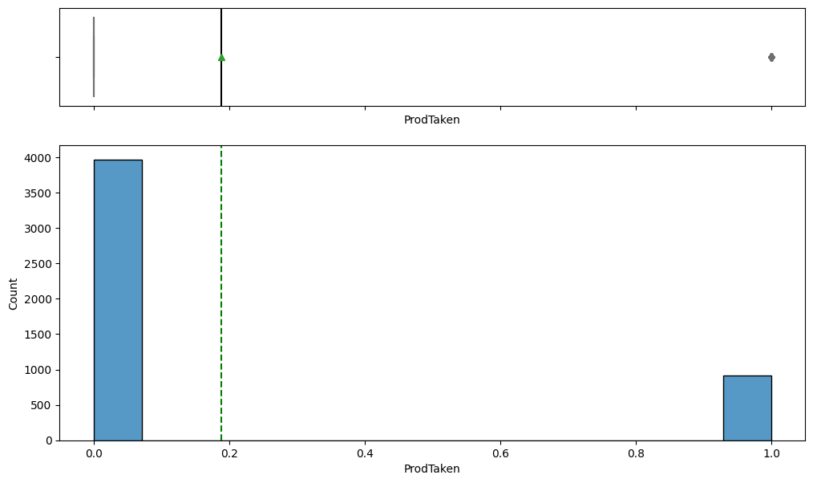

```python
histogram_boxplot(df_tourism,'ProdTaken')
```

**Observations:**

- Maximum customers not purchased the package.
- < 1000 customers purchased the package.

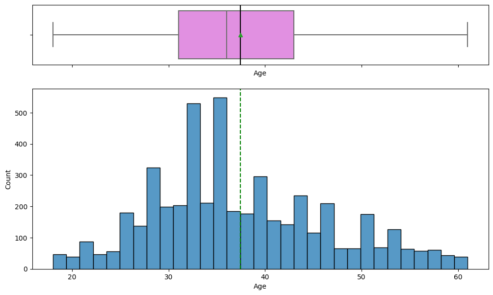

```python
histogram_boxplot(df_tourism,'Age')
```

**Observations:**

- Data is fairly normally distributed.

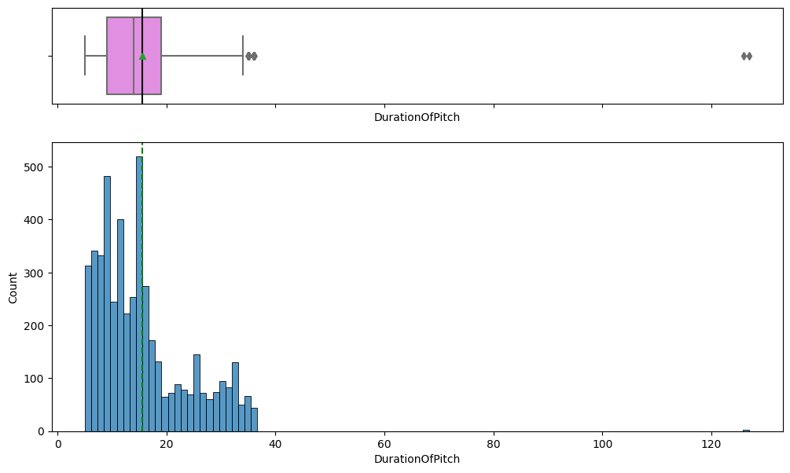

```python
histogram_boxplot(df_tourism,'DurationOfPitch')
```

**Observations**

- Distribution is right skew.
- There are few pitches which seems like a too high.

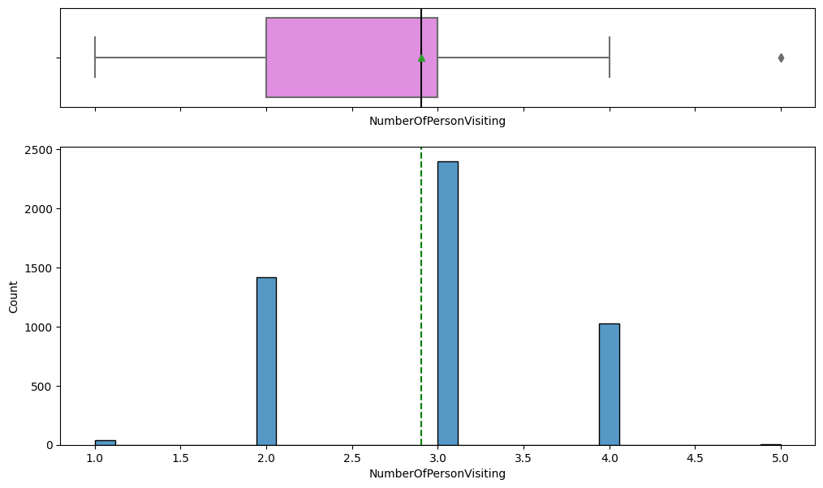

```python
histogram_boxplot(df_tourism,'NumberOfPersonVisiting')
```

**Observations**

- NumberOfPersonVisiting is the descrete variable.
- There are customers visting with 5 persons also and can not consider a true outlier.

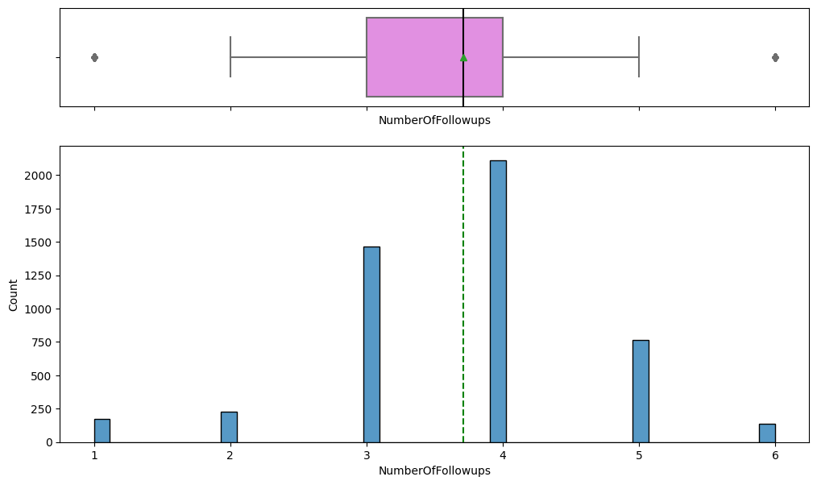

```python
histogram_boxplot(df_tourism,'NumberOfFollowups')
```

*Observations:

- Maximum number of follow up by salespersons are 4 follwed by 3 .

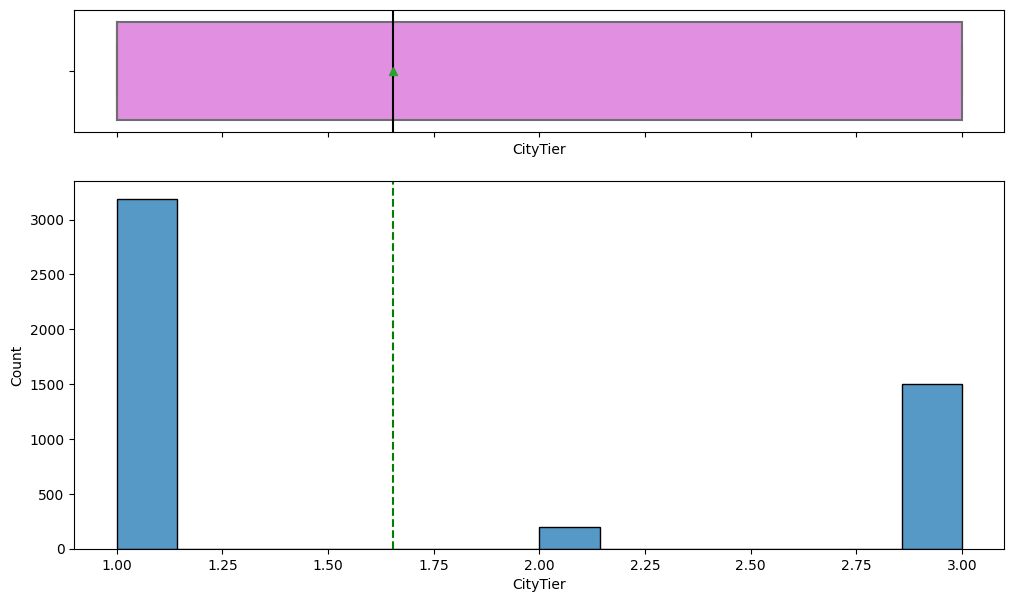

```python
histogram_boxplot(df_tourism,'CityTier')
```

**Observations**

- Maximum customers are from Tier1 city , followed by Tier3 .
- Few customers are from Tier2.

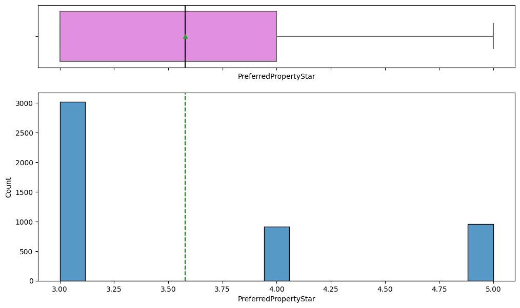

```python
histogram_boxplot(df_tourism,'PreferredPropertyStar')
```

**Observations**

- Maximum hotels from category 3,followed by 5 and 3.

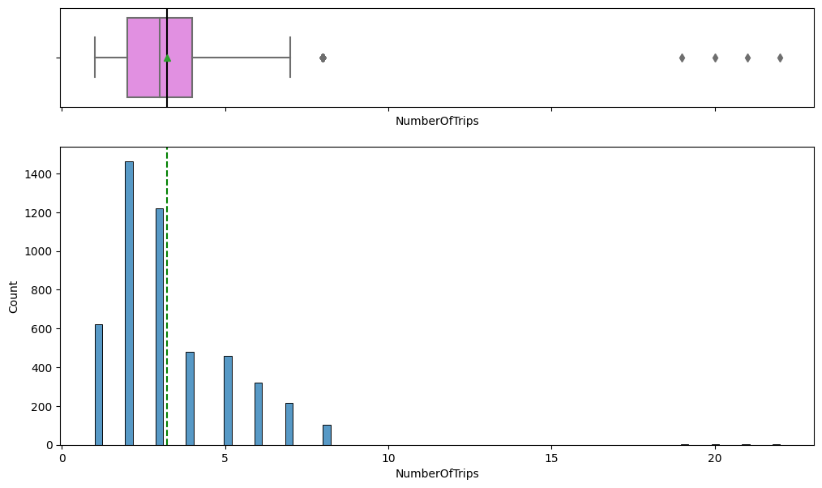

```python
histogram_boxplot(df_tourism,'NumberOfTrips')
```

**Observations**

- Maximum trips per year is 2, followed by 3.
- Some of the customers having more than 15 trips per years which is sightly high , may be these customers did business trip also , hence not considering as true outliers.

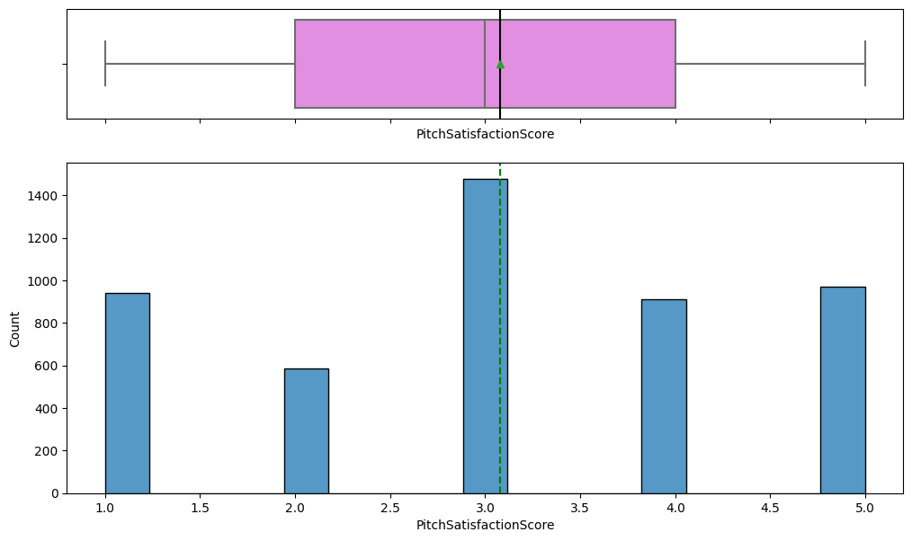

```python
histogram_boxplot(df_tourism,'PitchSatisfactionScore')
```

**Observations**

- Maximum salesperson having 3 satisfaction score.
- Salesperson having 1 satisfication score which is low.

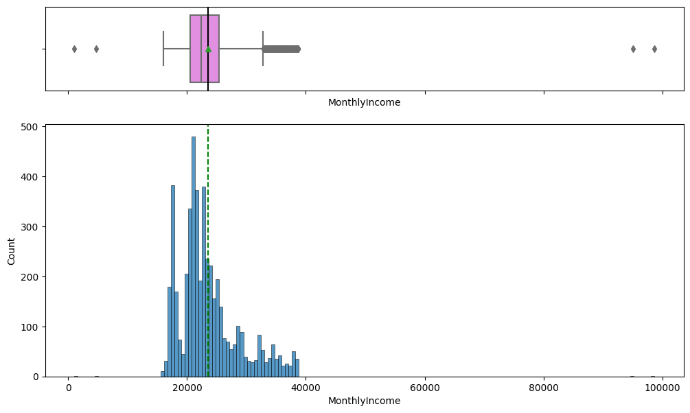

```python
histogram_boxplot(df_tourism,'MonthlyIncome')
```

**Observations**

- Data is right skew.
- Getting lots of outliers but these seems like not a true outliers. Customers can have more than 40000/ month income.

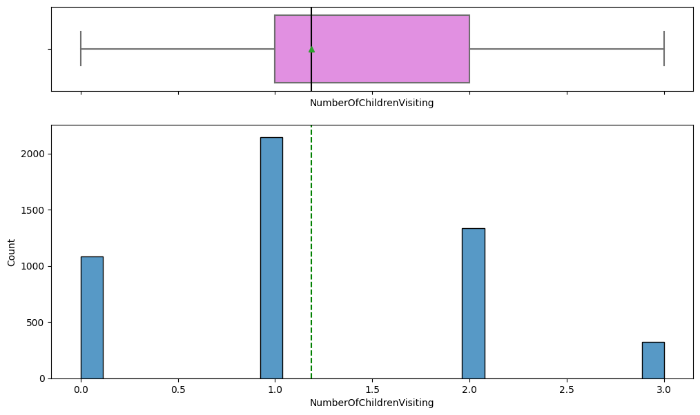

```python
histogram_boxplot(df_tourism,'NumberOfChildrenVisiting')
```

**Observations**

- Maximum customers are travelling with one child .
- Customers are also travelling without childeren .

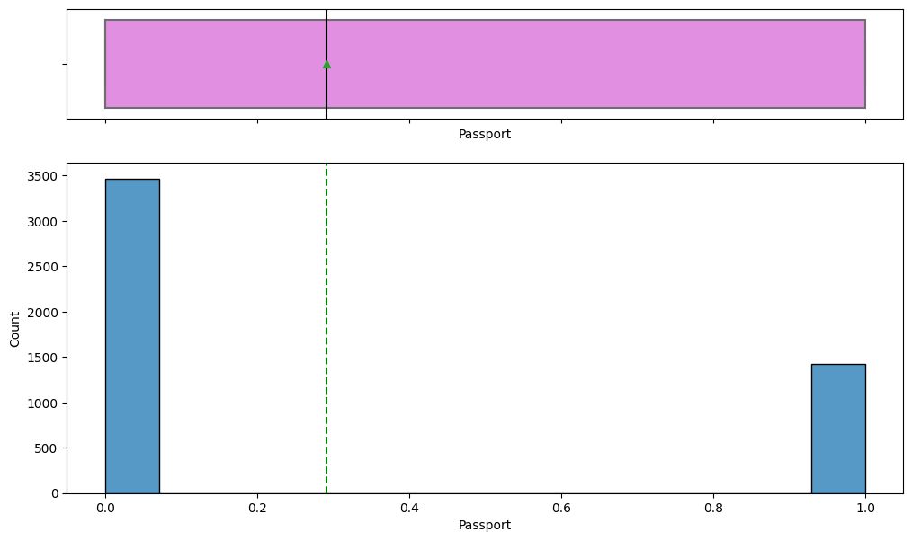

```python
histogram_boxplot(df_tourism,'Passport')
```

**Observations**

- Maximum customers don't have passport .

```python
# function to create labeled barplots


def labeled_barplot(data, feature, perc=False, n=None):
    """
    Barplot with percentage at the top

    data: dataframe
    feature: dataframe column
    perc: whether to display percentages instead of count (default is False)
    n: displays the top n category levels (default is None, i.e., display all levels)
    """

    total = len(data[feature])  # length of the column
    count = data[feature].nunique()
    if n is None:
        plt.figure(figsize=(count + 1, 5))
    else:
        plt.figure(figsize=(n + 1, 5))

    plt.xticks(rotation=90, fontsize=15)
    ax = sns.countplot(
        data=data,
        x=feature,
        palette="Paired",
        order=data[feature].value_counts().index[:n],
    )

    for p in ax.patches:
        if perc == True:
            label = "{:.1f}%".format(
                100 * p.get_height() / total
            )  # percentage of each class of the category
        else:
            label = p.get_height()  # count of each level of the category

        x = p.get_x() + p.get_width() / 2  # width of the plot
        y = p.get_height()  # height of the plot

        ax.annotate(
            label,
            (x, y),
            ha="center",
            va="center",
            size=12,
            xytext=(0, 5),
            textcoords="offset points",
        )  # annotate the percentage

    plt.show()  # show the plot
```

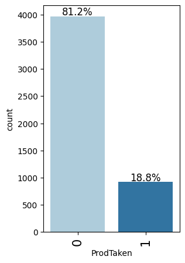

```python
labeled_barplot(df_tourism,'ProdTaken',perc=True)
```

**Observations**

- 81.2% customers did not purchase tourist package .
- Only 18.8% customers purchased tourist package from the company.
- The target classification is imbalanced as there are only 18.8% customers purchased tourist package .

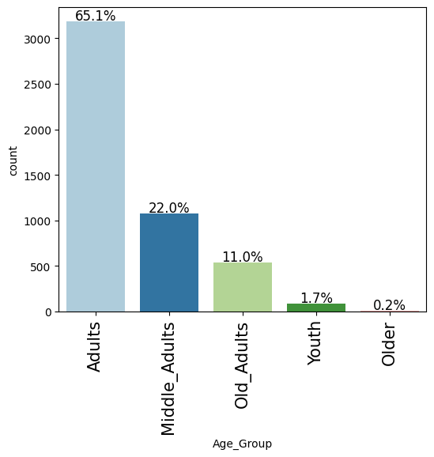

```python
labeled_barplot(df_tourism,'Age_Group',perc=True)
```

**Observations**

**Bivariate Analysis**

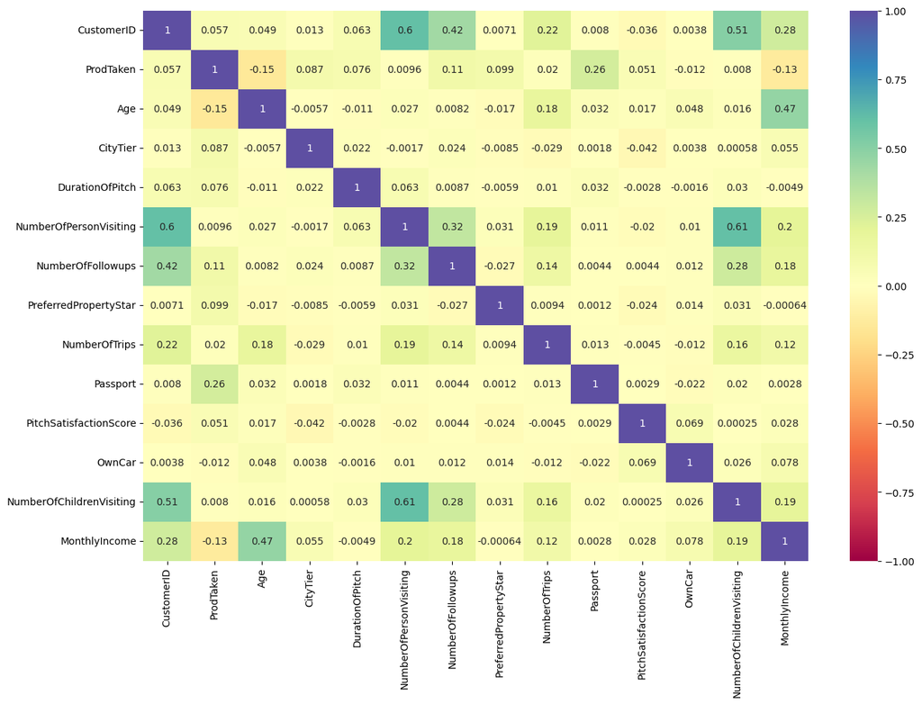

```python
plt.figure(figsize=(15,10))
df_tourism_corr = df_tourism.corr()
sns.heatmap(df_tourism_corr,annot=True,vmin= -1, vmax= 1, cmap='Spectral');
plt.show()
```

**Observations**

# Outlier Detection and Treatment

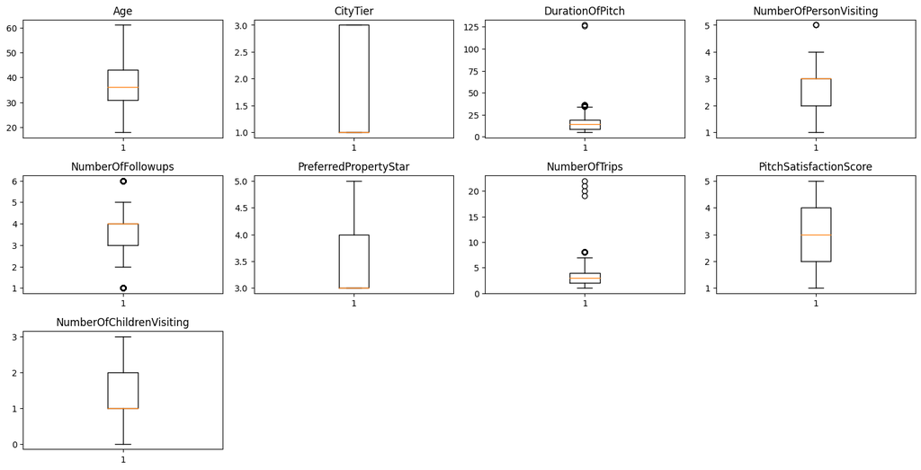

```python
numeric_columns = ['Age','CityTier','DurationOfPitch','NumberOfPersonVisiting','NumberOfFollowups','PreferredPropertyStar','NumberOfTrips'
,'PitchSatisfactionScore','NumberOfChildrenVisiting']

plt.figure(figsize=(15,10))
for i, variable in enumerate(numeric_columns):
  plt.subplot(4,4,i+1)
  plt.boxplot(df_tourism[variable])
  plt.tight_layout()
  plt.title(variable)
plt.show()
```

**Observations**

- There are few features having outliers but these are not true outliers .
- some data points having DurationOfPitch values greater than 35 because are quite high so will consider this as outlier and handle.

```python
# handle DurationOfPitch
quantile = np.quantile(df_tourism['DurationOfPitch'],[.25,.75])
IQR = quantile[1] - quantile[0]

lower_wishker = quantile[1] - 1.5*(IQR)
upper_wishker = quantile[1] + 1.5*(IQR)

df_tourism['DurationOfPitch'] = np.clip(df_tourism['DurationOfPitch'],lower_wishker,upper_wishker)
```

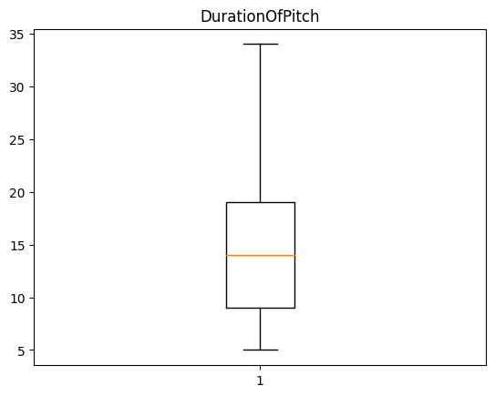

```python
# bar plot after outlier treatment
plt.boxplot(df_tourism['DurationOfPitch'])
plt.title('DurationOfPitch')
plt.show()
```

**Data Preparation for Modeling**

```python
# Seperate features and target columns
df_tourism.drop(columns=['CustomerID','Age'], inplace= True)
X = df_tourism.drop('ProdTaken', axis=1)
y = df_tourism['ProdTaken']
```

```python
# get dummy variables
X = pd.get_dummies(
    X,
    drop_first=True
)
```

```python
# Splitting data into training and test data set:
X_train,X_test,y_train,y_test = train_test_split(X, y, test_size=.3,random_state=1, stratify=y)
print(f'Training Data: {X_train.shape}, Test Data: {X_test.shape}')
```

```
Training Data: (3421, 32), Test Data: (1467, 32)
```

# Model evaluation criterion

**The model can make wrong predictions as:**

1. Customers most likely buy the wellness package but model predict that they will not buy.(FN)
2. Customers will not buy the wellness package but model predict that they will buy.(FP)

**Which case is more important?**

1. If the model predict that customer will not buy the wellness package but actually they will buy. This will occur as loss of revenue.
2. If the model predict that custome will buy the wellness packaage but actually they will not buy. This will occur as loss of resources.

**Which metric to optimize?**

- As per problem statement , company would like to target customers who will purchase wellness package . so our model should not predict those customers who will not buy. (Reduce the FN, maximizing the recall)

```python
# defining a function to compute different metrics to check performance of a classification model built using sklearn
def model_performance_classification_sklearn(model, predictors, target):
    """
    Function to compute different metrics to check classification model performance

    model: classifier
    predictors: independent variables
    target: dependent variable
    """

    # predicting using the independent variables
    pred = model.predict(predictors)

    acc = accuracy_score(target, pred)  # to compute Accuracy
    recall = recall_score(target, pred)  # to compute Recall
    precision = precision_score(target, pred)  # to compute Precision
    f1 = f1_score(target, pred)  # to compute F1-score

    # creating a dataframe of metrics
    df_perf = pd.DataFrame(
        {
            "Accuracy": acc,
            "Recall": recall,
            "Precision": precision,
            "F1": f1,
        },
        index=[0],
    )

    return df_perf
```

```python
def confusion_matrix_sklearn(model, predictors, target):
    """
    To plot the confusion_matrix with percentages

    model: classifier
    predictors: independent variables
    target: dependent variable
    """
    y_pred = model.predict(predictors)
    cm = confusion_matrix(target, y_pred)
    labels = np.asarray(
        [
            ["{0:0.0f}".format(item) + "\n{0:.2%}".format(item / cm.flatten().sum())]
            for item in cm.flatten()
        ]
    ).reshape(2, 2)

    plt.figure(figsize=(6, 4))
    sns.heatmap(cm, annot=labels, fmt="")
    plt.ylabel("True label")
    plt.xlabel("Predicted label")
```

# Model Building and Hyperparameter Tuning

# Decision Tree - Default

```
Training performance:
    Accuracy  Recall  Precision   F1
0       1.0     1.0        1.0  1.0
Testing performance:
    Accuracy    Recall  Precision        F1
0  0.873892  0.717391    0.64918  0.681583
```

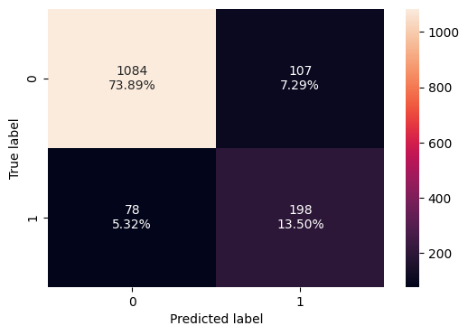

```python
d_tree = DecisionTreeClassifier(random_state=1)
d_tree.fit(X_train,y_train)

# calculate different matrix
d_tree_model_train_perf = model_performance_classification_sklearn(d_tree,X_train,y_train)
print("Training performance:\n",d_tree_model_train_perf)
d_tree_model_test_perf=model_performance_classification_sklearn(d_tree,X_test,y_test)
print("Testing performance:\n",d_tree_model_test_perf)

# Confusion matrix
confusion_matrix_sklearn(d_tree,X_test, y_test)
```

- Decision tree overfitting the training data.
- Let's try hyperparameter tuning and see if model performace improve.

# Decision Tree - Hyperparameter Tuning

```python
dtree_classifier = DecisionTreeClassifier(class_weight='balanced')
parameters = {
    'max_depth': np.arange(2,30),
    'min_samples_leaf': [1, 2, 5, 7, 10],
    'max_leaf_nodes' : [2, 3, 5, 10,15],
    'min_impurity_decrease': [0.0001,0.001,0.01,0.1]
}

# Type of scoring used to compare parameter combinations
score = metrics.make_scorer(metrics.f1_score)

# run the grid search
grid_obj = GridSearchCV(estimator=dtree_classifier,param_grid=parameters,scoring=score,n_jobs=-1)
grid_obj = grid_obj.fit(X_train,y_train)
```

```python
# set the clf to the best combination of parameters
dtree_classifier = grid_obj.best_estimator_

# Fit the best algorithm to the data.
dtree_classifier.fit(X_train,y_train)
```

```
DecisionTreeClassifier(class_weight='balanced', max_depth=5, max_leaf_nodes=15,
                       min_impurity_decrease=0.0001)
```

```
Training performance:
    Accuracy    Recall  Precision        F1
0  0.766735  0.692547   0.426386  0.527811
Testing performance:
    Accuracy    Recall  Precision       F1
0  0.755965  0.695652   0.412017  0.51752
```

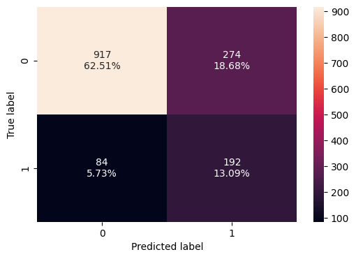

```python
# calculate different matrix
dtree_classifier_model_train_perf = model_performance_classification_sklearn(dtree_classifier,X_train,y_train)
print("Training performance:\n",dtree_classifier_model_train_perf)
dtree_classifier_model_test_perf=model_performance_classification_sklearn(dtree_classifier,X_test,y_test)
print("Testing performance:\n",dtree_classifier_model_test_perf)

# Confusion matrix
confusion_matrix_sklearn(dtree_classifier,X_test, y_test)
```

- Recall is approximate equal for train and test data but less that default decision tree recall .
- Hyperparameter tuning did not improve the recall. Let's try other algorthim.

# Bagging - RandomForestClassifier(Default)

```python
rf_classifier = RandomForestClassifier(random_state=1)
rf_classifier.fit(X_train,y_train)
```

```
RandomForestClassifier(random_state=1)
```

```
Training performance:
    Accuracy  Recall  Precision   F1
0       1.0     1.0        1.0  1.0
Testing performance:
    Accuracy    Recall  Precision        F1
0  0.909339  0.568841   0.918129  0.702461
```

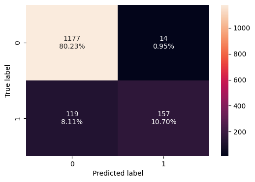

```python
# calculate different matrix
rf_classifier_model_train_perf = model_performance_classification_sklearn(rf_classifier,X_train,y_train)
print("Training performance:\n",rf_classifier_model_train_perf)
rf_classifier_model_test_perf=model_performance_classification_sklearn(rf_classifier,X_test,y_test)
print("Testing performance:\n",rf_classifier_model_test_perf)

# Confusion matrix
confusion_matrix_sklearn(rf_classifier,X_test, y_test)
```

- RandomForest classifier overfitting the training data.
- Let's try the hyperparameter tuning and see if model performace improve.

# Bagging - RandomForestClassifier (Hyperparameter Tuning)

```python
rf_tuned = RandomForestClassifier(random_state=1, class_weight='balanced',bootstrap=True)
parameters = {
                'max_depth': np.arange(5,30,5),
                'max_features': ['sqrt','log2'],
                #'min_samples_leaf': np.arange(1,15,5),
                #'min_samples_split': np.arange(2, 20, 5),
                'n_estimators': np.arange(10,110,10)
                }
 # Type of scoring used to compare parameter combinations
scorer = metrics.make_scorer(metrics.recall_score)

 # run the grid search
grid_obj = GridSearchCV(rf_tuned, param_grid=parameters, scoring=scorer, cv = 5, n_jobs=-1, verbose=2)
grid_obj = grid_obj.fit(X_train,y_train)

 # set the best classifier
rf_tuned = grid_obj.best_estimator_

# fit the model against the best estimator
rf_tuned.fit(X_train,y_train)
```

```
Fitting 5 folds for each of 100 candidates, totalling 500 fits
```

```
RandomForestClassifier(class_weight='balanced', max_depth=5, n_estimators=20,
                       random_state=1)
```

```
Training performance:
    Accuracy    Recall  Precision       F1
0  0.808536  0.706522   0.494028  0.58147
Testing performance:
    Accuracy    Recall  Precision        F1
0  0.802318  0.721014    0.48301  0.578488
```

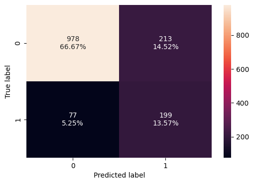

```python
#Calculating different metrics
rf_tuned_model_train_perf=model_performance_classification_sklearn(rf_tuned,X_train,y_train)
print("Training performance:\n",rf_tuned_model_train_perf)
rf_tuned_model_test_perf=model_performance_classification_sklearn(rf_tuned,X_test,y_test)
print("Testing performance:\n",rf_tuned_model_test_perf)

#Creating confusion matrix
confusion_matrix_sklearn(rf_tuned,X_test,y_test)
```

- The overfitting has reduced significantly and the model performance has improved.
- Model is giving the generalized performance on unseen data.

# Bagging Classifier (Default)

```python
# fitting the model
bagging_classifier = BaggingClassifier(random_state=1)
bagging_classifier.fit(X_train,y_train)
```

```
BaggingClassifier(random_state=1)
```

```
Training performance:
    Accuracy   Recall  Precision        F1
0  0.994154  0.97205   0.996815  0.984277
Testing performance:
    Accuracy    Recall  Precision        F1
0  0.897751  0.568841   0.835106  0.676724
```

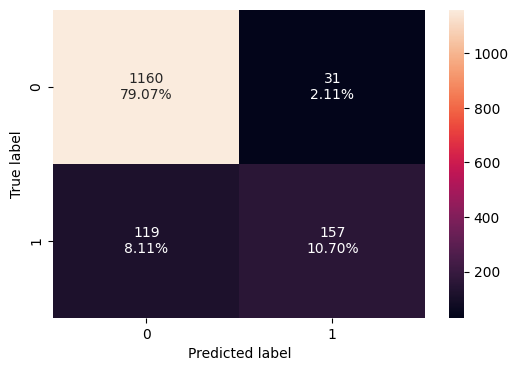

```python
# calculate different matrix
bagging_classifier_model_train_perf = model_performance_classification_sklearn(bagging_classifier,X_train,y_train)
print("Training performance:\n",bagging_classifier_model_train_perf)
bagging_classifier_model_test_perf=model_performance_classification_sklearn(bagging_classifier,X_test,y_test)
print("Testing performance:\n",bagging_classifier_model_test_perf)

# Confusion matrix
confusion_matrix_sklearn(bagging_classifier,X_test, y_test)
```

- Bagging classifier(Default) overfitting the training data.
- Let's try the hyperparameter tuning and see if model performace improve.

# Bagging Classifier - Hyperparameter Tuning

```python
bagging_classifier_tuned = BaggingClassifier(random_state=42)
parameters = {
              'max_samples': [0.7,0.8,0.9,1],
              'max_features': [0.7,0.8,0.9,1],
              'n_estimators' : [10,20,30,40,50]
}

scorer = metrics.make_scorer(metrics.recall_score)
grid_obj = GridSearchCV(bagging_classifier_tuned, param_grid=parameters,scoring=score,cv =5, n_jobs=-1, verbose=2)
grid_obj.fit(X_train,y_train)
```

```
Fitting 5 folds for each of 80 candidates, totalling 400 fits
```

```
GridSearchCV(cv=5, estimator=BaggingClassifier(random_state=42), n_jobs=-1,
             param_grid={'max_features': [0.7, 0.8, 0.9, 1],
                         'max_samples': [0.7, 0.8, 0.9, 1],
                         'n_estimators': [10, 20, 30, 40, 50]},
             scoring=make_scorer(f1_score), verbose=2)
```

```python
# set the clf to the best combination of parameters
bagging_classifier_tuned = grid_obj.best_estimator_

# fit the model
bagging_classifier_tuned = bagging_classifier_tuned.fit(X_train,y_train)
```

```
Training performance:
    Accuracy    Recall  Precision        F1
0  0.999708  0.998447        1.0  0.999223
Testing performance:
    Accuracy    Recall  Precision        F1
0  0.915474  0.619565        0.9  0.733906
```

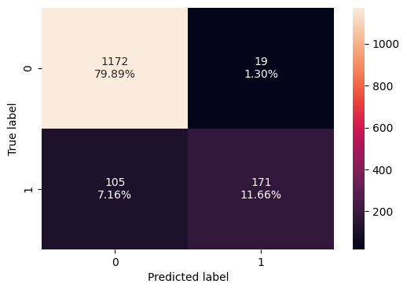

```python
# calculate different matrix
bagging_classifier_tuned_model_train_perf = model_performance_classification_sklearn(bagging_classifier_tuned,X_train,y_train)
print("Training performance:\n",bagging_classifier_tuned_model_train_perf)
bagging_classifier_tuned_model_test_perf=model_performance_classification_sklearn(bagging_classifier_tuned,X_test,y_test)
print("Testing performance:\n",bagging_classifier_tuned_model_test_perf)

# Confusion matrix
confusion_matrix_sklearn(bagging_classifier_tuned,X_test, y_test)
```

- Bagging classifier(Hyperparameter tuning) overfitting the training data.
- Let's try the hyperparameter tuning and see if model performace improve.

# Boosting - AdaBoost (Default)

```python
# Fitting the model
ab_classifier = AdaBoostClassifier(random_state=1)
ab_classifier.fit(X_train,y_train)
```

```
AdaBoostClassifier(random_state=1)
```

```
Training performance:
    Accuracy    Recall  Precision        F1
0   0.84069  0.301242    0.67128  0.415863
Testing performance:
    Accuracy    Recall  Precision        F1
0  0.843217  0.293478   0.698276  0.413265
```

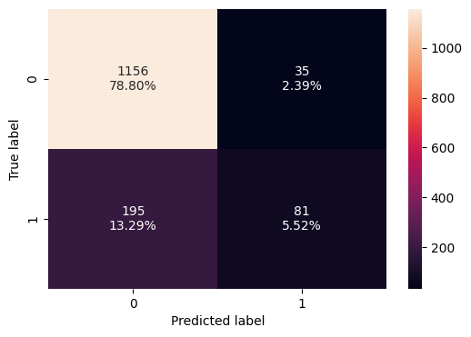

```python
# calculate different matrix
ab_classifier_model_train_perf = model_performance_classification_sklearn(ab_classifier,X_train,y_train)
print("Training performance:\n",ab_classifier_model_train_perf)
ab_classifier_model_test_perf=model_performance_classification_sklearn(ab_classifier,X_test,y_test)
print("Testing performance:\n",ab_classifier_model_test_perf)

# Confusion matrix
confusion_matrix_sklearn(ab_classifier,X_test, y_test)
```

- AdaBoost giving the generalized performance but recall is too low.
- Let's try the hyperparameter tuning and check the model performance.

# Boosting - AdaBoost (Hyperparameter Tuning)

```python
# Choose the type of classifier.
abc_tuned = AdaBoostClassifier(random_state=1)

# Grid of parameters to choose from
parameters = {
    #Let's try different max_depth for estimator
    "estimator":[DecisionTreeClassifier(max_depth=1),DecisionTreeClassifier(max_depth=2),
                      DecisionTreeClassifier(max_depth=3)],
    "n_estimators": np.arange(10,110,10),
    "learning_rate":np.arange(0.1,2,0.1)
}

# Type of scoring used to compare parameter  combinations
scorer = metrics.make_scorer(metrics.recall_score)

# Run the grid search
grid_obj = GridSearchCV(abc_tuned, parameters, scoring=scorer,cv=5)
grid_obj = grid_obj.fit(X_train, y_train)

# Set the clf to the best combination of parameters
abc_tuned = grid_obj.best_estimator_

# Fit the best algorithm to the data.
abc_tuned.fit(X_train, y_train)
```

```
AdaBoostClassifier(estimator=DecisionTreeClassifier(max_depth=3),
                   learning_rate=1.2000000000000002, n_estimators=100,
                   random_state=1)
```

```
Training performance:
    Accuracy    Recall  Precision        F1
0  0.988308  0.953416   0.983974  0.968454
Testing performance:
    Accuracy    Recall  Precision        F1
0  0.874574  0.634058   0.678295  0.655431
```

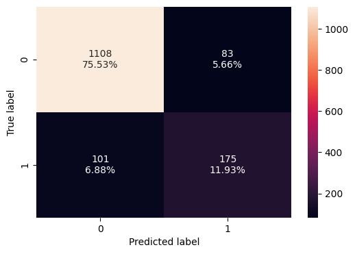

```python
# calculate different matrix
abc_tuned_model_train_perf = model_performance_classification_sklearn(abc_tuned,X_train,y_train)
print("Training performance:\n",abc_tuned_model_train_perf)
abc_tuned_model_test_perf=model_performance_classification_sklearn(abc_tuned,X_test,y_test)
print("Testing performance:\n",abc_tuned_model_test_perf)

# Confusion matrix
confusion_matrix_sklearn(abc_tuned,X_test, y_test)
```

- Recall is increased compare to default adaboost but still model overfitting the training dataset.
- Let's try another model and check the performance.

# Gradient Boosting Classifier

```
Training performance:
    Accuracy    Recall  Precision       F1
0  0.880152  0.434783   0.858896  0.57732
Testing performance:
    Accuracy    Recall  Precision        F1
0  0.863667  0.376812   0.787879  0.509804
```

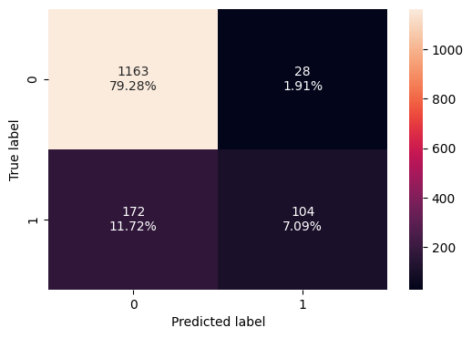

```python
#Fitting the model
gb_classifier = GradientBoostingClassifier(random_state=1)
gb_classifier.fit(X_train,y_train)

#Calculating different metrics
gb_classifier_model_train_perf=model_performance_classification_sklearn(gb_classifier,X_train,y_train)
print("Training performance:\n",gb_classifier_model_train_perf)
gb_classifier_model_test_perf=model_performance_classification_sklearn(gb_classifier,X_test,y_test)
print("Testing performance:\n",gb_classifier_model_test_perf)

#Creating confusion matrix
confusion_matrix_sklearn(gb_classifier,X_test,y_test)
```

- The gradient boosting classifier is overfitting the training data.

# Gradient Boosting Classifier - Hyperparameters

```python
# choose the type of classifier
gbc_tuned = GradientBoostingClassifier(init = AdaBoostClassifier(random_state=1), random_state=1)

# Grid of parameters to choose from
parameters = {
    "n_estimators": [100,150,200,250],
    "subsample":[0.8,0.9,1],
    "max_features":[0.7,0.8,0.9,1]
}

scorer = metrics.make_scorer(metrics.recall_score)
grid_obj = GridSearchCV(gbc_tuned,param_grid=parameters,scoring=score,cv= 5)
grid_obj.fit(X_train,y_train)

gbc_tuned = grid_obj.best_estimator_
gbc_tuned.fit(X_train,y_train)
```

```
GradientBoostingClassifier(init=AdaBoostClassifier(random_state=1),
                           max_features=0.8, n_estimators=250, random_state=1,
                           subsample=0.9)
```

```
Training performance:
    Accuracy    Recall  Precision        F1
0  0.911137  0.580745   0.916667  0.711027
Testing performance:
    Accuracy    Recall  Precision        F1
0  0.876619  0.471014   0.787879  0.589569
```

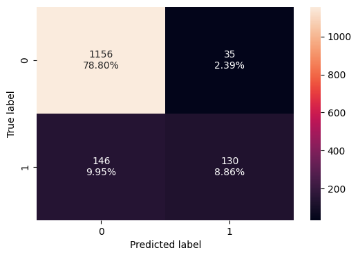

```python
#Calculating different metrics
gbc_tuned_model_train_perf=model_performance_classification_sklearn(gbc_tuned,X_train,y_train)
print("Training performance:\n",gbc_tuned_model_train_perf)
gbc_tuned_model_test_perf=model_performance_classification_sklearn(gbc_tuned,X_test,y_test)
print("Testing performance:\n",gbc_tuned_model_test_perf)

#Creating confusion matrix
confusion_matrix_sklearn(gbc_tuned,X_test,y_test)
```

- The gradient boosting classifier (hyperparameter tuning) is overfitting the training data.

# XGBoost Classifier

```
Training performance:
    Accuracy    Recall  Precision        F1
0  0.999415  0.996894        1.0  0.998445
Testing performance:
    Accuracy    Recall  Precision        F1
0  0.920927  0.699275   0.853982  0.768924
```

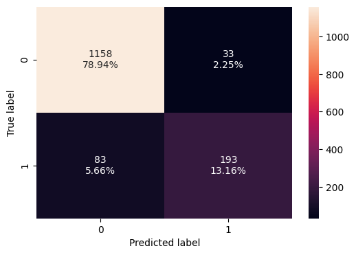

```python
#Fitting the model
xgb_classifier = XGBClassifier(random_state=1, eval_metric='logloss')
xgb_classifier.fit(X_train,y_train)

#Calculating different metrics
xgb_classifier_model_train_perf=model_performance_classification_sklearn(xgb_classifier,X_train,y_train)
print("Training performance:\n",xgb_classifier_model_train_perf)
xgb_classifier_model_test_perf=model_performance_classification_sklearn(xgb_classifier,X_test,y_test)
print("Testing performance:\n",xgb_classifier_model_test_perf)

#Creating confusion matrix
confusion_matrix_sklearn(xgb_classifier,X_test,y_test)
```

- The XGBoost Classifier (Default) is overfitting the training data.

# XGBoost Classifier - Hyperparameter Tuning

```python
# Choose the type of classifier.
xgb_tuned = XGBClassifier(random_state=1, eval_metric='logloss')

# Grid of parameters to choose from
parameters = {
    "n_estimators": [10,30,50],
    "scale_pos_weight":[1,2,5],
    "subsample":[0.7,0.9,1],
    "learning_rate":[0.05, 0.1,0.2],
    "colsample_bytree":[0.7,0.9,1],
    "colsample_bylevel":[0.5,0.7,1]
}

# Type of scoring used to compare parameter combinations
scorer = metrics.make_scorer(metrics.recall_score)

# Run the grid search
grid_obj = GridSearchCV(xgb_tuned, parameters,scoring=scorer,cv=5)
grid_obj = grid_obj.fit(X_train, y_train)

# Set the clf to the best combination of parameters
xgb_tuned = grid_obj.best_estimator_

# Fit the best algorithm to the data.
xgb_tuned.fit(X_train, y_train)
```

```
XGBClassifier(base_score=None, booster=None, callbacks=None,
              colsample_bylevel=0.7, colsample_bynode=None,
              colsample_bytree=0.7, early_stopping_rounds=None,
              enable_categorical=False, eval_metric='logloss',
              feature_types=None, gamma=None, gpu_id=None, grow_policy=None,
              importance_type=None, interaction_constraints=None,
              learning_rate=0.2, max_bin=None, max_cat_threshold=None,
              max_cat_to_onehot=None, max_delta_step=None, max_depth=None,
              max_leaves=None, min_child_weight=None, missing=nan,
              monotone_constraints=None, n_estimators=30, n_jobs=None,
              num_parallel_tree=None, predictor=None, random_state=1, ...)
```

```
Training performance:
    Accuracy    Recall  Precision        F1
0  0.935984  0.975155   0.755716  0.851525
Testing performance:
    Accuracy    Recall  Precision        F1
0  0.871166  0.818841   0.619178  0.705148
```

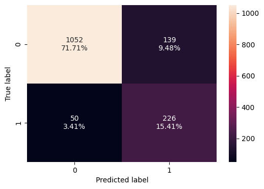

```python
#Calculating different metrics
xgb_tuned_model_train_perf=model_performance_classification_sklearn(xgb_tuned,X_train,y_train)
print("Training performance:\n",xgb_tuned_model_train_perf)
xgb_tuned_model_test_perf=model_performance_classification_sklearn(xgb_tuned,X_test,y_test)
print("Testing performance:\n",xgb_tuned_model_test_perf)

#Creating confusion matrix
confusion_matrix_sklearn(xgb_tuned,X_test,y_test)
```

- XGBoost classifier (Hyperparameter) overfittig the training dataset but recall has increased significantly .

# Stacking model

```python
estimators = [('Gradient Boosting',gbc_tuned), ('Decision Tree',dtree_classifier)]

final_estimator = xgb_tuned

stacking_classifier= StackingClassifier(estimators=estimators,final_estimator=final_estimator)

stacking_classifier.fit(X_train,y_train)
```

```
StackingClassifier(estimators=[('Gradient Boosting',
                                GradientBoostingClassifier(init=AdaBoostClassifier(random_state=1),
                                                           max_features=0.8,
                                                           n_estimators=250,
                                                           random_state=1,
                                                           subsample=0.9)),
                               ('Decision Tree',
                                DecisionTreeClassifier(class_weight='balanced',
                                                       max_depth=5,
                                                       max_leaf_nodes=15,
                                                       min_impurity_decrease=0.0001))],
                   final_estimator=XGBClassifier(base_score=N...
                                                 gpu_id=None, grow_policy=None,
                                                 importance_type=None,
                                                 interaction_constraints=None,
                                                 learning_rate=0.2,
                                                 max_bin=None,
                                                 max_cat_threshold=None,
                                                 max_cat_to_onehot=None,
                                                 max_delta_step=None,
                                                 max_depth=None,
                                                 max_leaves=None,
                                                 min_child_weight=None,
                                                 missing=nan,
                                                 monotone_constraints=None,
                                                 n_estimators=30, n_jobs=None,
                                                 num_parallel_tree=None,
                                                 predictor=None, random_state=1, ...))
```

```
Training performance:
    Accuracy    Recall  Precision        F1
0  0.833382  0.804348   0.538462  0.645081
Testing performance:
    Accuracy   Recall  Precision        F1
0  0.791411  0.73913   0.465753  0.571429
```

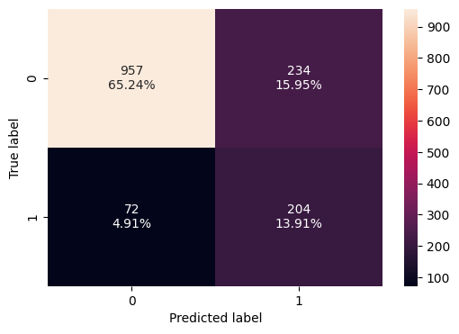

```python
#Calculating different metrics
stacking_classifier_model_train_perf=model_performance_classification_sklearn(stacking_classifier,X_train,y_train)
print("Training performance:\n",stacking_classifier_model_train_perf)
stacking_classifier_model_test_perf=model_performance_classification_sklearn(stacking_classifier,X_test,y_test)
print("Testing performance:\n",stacking_classifier_model_test_perf)

#Creating confusion matrix
confusion_matrix_sklearn(stacking_classifier,X_test,y_test)
```

- The stacking classifier is giving a slightly less performance as compared to XGBoost tuned with slightly less overfitting.

# Comparing all models

```python
models_train_comp_df = pd.concat(
    [
       d_tree_model_train_perf.T,
       dtree_classifier_model_train_perf.T ,
       rf_classifier_model_train_perf.T,
       rf_tuned_model_train_perf.T,
       bagging_classifier_model_train_perf.T,
       bagging_classifier_tuned_model_train_perf.T,
       ab_classifier_model_train_perf.T,
       abc_tuned_model_train_perf.T,
       gb_classifier_model_train_perf.T,
       gbc_tuned_model_train_perf.T,
       xgb_classifier_model_train_perf.T,
       xgb_tuned_model_train_perf.T,
       stacking_classifier_model_train_perf.T
    ],
    axis = 1
)

models_train_comp_df.columns = [
    'Decision Tree',
    'Decision Tree - Tuned',
    'Random Forest Classifier',
    'Random Forest Classifier - Tuned',
    'Bagging Classifier',
    'Bagging Classifier - Tuned',
    'AdaBoost',
    'AdaBoost - Tuned',
    'Gradient Boosting',
    'Gradient Boosting - Tuned',
    'XGBoost',
    'XGBoost - Tuned',
    'Stacking Classifier'
]

models_train_comp_df
```

|  | Decision Tree | Decision Tree - Tuned | Random Forest Classifier | Random Forest Classifier - Tuned | Bagging Classifier | Bagging Classifier - Tuned | AdaBoost | AdaBoost - Tuned | Gradient Boosting | Gradient Boosting - Tuned | XGBoost | XGBoost - Tuned | Stacking Classifier |
| --- | --- | --- | --- | --- | --- | --- | --- | --- | --- | --- | --- | --- | --- |
| Accuracy | 1.0 | 0.766735 | 1.0 | 0.808536 | 0.994154 | 0.999708 | 0.840690 | 0.988308 | 0.880152 | 0.911137 | 0.999415 | 0.935984 | 0.833382 |
| Recall | 1.0 | 0.692547 | 1.0 | 0.706522 | 0.972050 | 0.998447 | 0.301242 | 0.953416 | 0.434783 | 0.580745 | 0.996894 | 0.975155 | 0.804348 |
| Precision | 1.0 | 0.426386 | 1.0 | 0.494028 | 0.996815 | 1.000000 | 0.671280 | 0.983974 | 0.858896 | 0.916667 | 1.000000 | 0.755716 | 0.538462 |
| F1 | 1.0 | 0.527811 | 1.0 | 0.581470 | 0.984277 | 0.999223 | 0.415863 | 0.968454 | 0.577320 | 0.711027 | 0.998445 | 0.851525 | 0.645081 |

```python
models_test_comp_df = pd.concat(
    [
       d_tree_model_test_perf.T,
       dtree_classifier_model_test_perf.T,
       rf_classifier_model_test_perf.T,
       rf_tuned_model_test_perf.T,
       bagging_classifier_model_test_perf.T,
       bagging_classifier_tuned_model_test_perf.T,
       ab_classifier_model_test_perf.T,
       abc_tuned_model_test_perf.T,
       gb_classifier_model_test_perf.T,
       gbc_tuned_model_test_perf.T,
       xgb_classifier_model_test_perf.T,
       xgb_tuned_model_test_perf.T,
       stacking_classifier_model_test_perf.T

    ],
    axis = 1
)

models_test_comp_df.columns = [
    'Decision Tree',
    'Decision Tree - Tuned',
    'Random Forest Classifier',
    'Random Forest Classifier - Tuned',
    'Bagging Classifier',
    'Bagging Classifier - Tuned',
    'AdaBoost',
    'AdaBoost - Tuned',
    'Gradient Boosting',
    'Gradient Boosting - Tuned',
    'XGBoost',
    'XGBoost - Tuned',
    'Stacking Classifier'
]
models_test_comp_df
```

|  | Decision Tree | Decision Tree - Tuned | Random Forest Classifier | Random Forest Classifier - Tuned | Bagging Classifier | Bagging Classifier - Tuned | AdaBoost | AdaBoost - Tuned | Gradient Boosting | Gradient Boosting - Tuned | XGBoost | XGBoost - Tuned | Stacking Classifier |
| --- | --- | --- | --- | --- | --- | --- | --- | --- | --- | --- | --- | --- | --- |
| Accuracy | 0.873892 | 0.755965 | 0.909339 | 0.802318 | 0.897751 | 0.915474 | 0.843217 | 0.874574 | 0.863667 | 0.876619 | 0.920927 | 0.871166 | 0.791411 |
| Recall | 0.717391 | 0.695652 | 0.568841 | 0.721014 | 0.568841 | 0.619565 | 0.293478 | 0.634058 | 0.376812 | 0.471014 | 0.699275 | 0.818841 | 0.739130 |
| Precision | 0.649180 | 0.412017 | 0.918129 | 0.483010 | 0.835106 | 0.900000 | 0.698276 | 0.678295 | 0.787879 | 0.787879 | 0.853982 | 0.619178 | 0.465753 |
| F1 | 0.681583 | 0.517520 | 0.702461 | 0.578488 | 0.676724 | 0.733906 | 0.413265 | 0.655431 | 0.509804 | 0.589569 | 0.768924 | 0.705148 | 0.571429 |

- Generalized models are
  - Decision Tree - Tuned
  - Random Forest classifier - Tuned
  - AdaBoost
- XGBoost - Tuned is giving the highest recall score but its overfitting the training data
- Stacking classifier is giving the second larget highest recal score but its overfitting the training data
- Random forest classifier - Tuned is giving the generalized result and recall is also considerable good.
- Decision tree - Tuned is also giving the generalized result but recall is slightly less than Random Forest - Tuned

# Feature importance

```python
# Function to plot the horizontal bar
def barh_feature_importance(model):
  feature_names = X_train.columns.tolist()
  importances = model.feature_importances_
  indices =  np.argsort(importances)

  plt.figure(figsize=(12,10))

  plt.title('Feature Importances')
  plt.barh(range(len(indices)), importances[indices], color='violet', align='center')
  plt.yticks(range(len(indices)), [feature_names[i] for i in indices])
  plt.xlabel('Relative Importance')
  plt.show()
```

- Random Forest Tuned

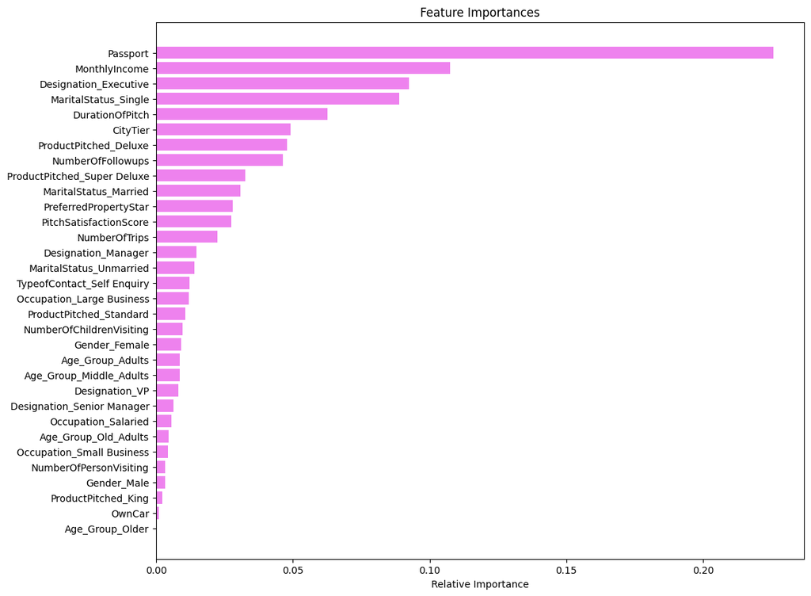

```python
barh_feature_importance(rf_tuned)
```

- Decision tree - Tuned

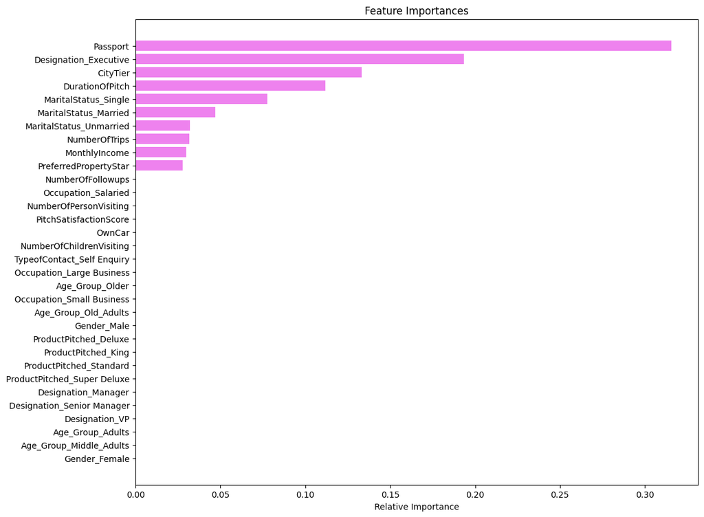

```python
barh_feature_importance(dtree_classifier)
```

- Passport is the most important feature to identify the customer to purchase the package .
- Customers who are in executive position will most likely to purchase the package.
- Customers whose marital status is 'Single' most likely to purchase the package compare to 'Married'.
- Most likely the customer will purchase the package if Duration of the piched provided by salesperson is large.
- Type of contact does not show significant contribution to purchase the package.

# Conclusions and Recommendations

- Based on our analysis passport is the most important factor to purchase the wellness package . hence initially company can target only those customers which having passport.
- Salary is also the another deciding factor and initially company should target only executive designation customers.
- Company can target single status customer. May be they are looking for some vacation package
- Initially company should look only Tier1 city customers.
- Duration of the pitch by the salesperson should be more attractive and good enough so that customers can decide soon.
- Deluxe product pitch should show to the customers.